# scPRINT use case on BPH (part 2, GN analysis)

In this use-case, which some of the results are presented in Figure 5 of our [manuscript](https://www.biorxiv.org/content/10.1101/2024.07.29.605556v1), we perform an extensive analysis of gene networks generated by scPRINT in our previous notebook for fibroblasts of the prostate in both normal and benign prostatic hyperplasia states.

We can look at many patterns from the gene networks such as hub genes, gene modules, and gene-gene interactions. Some of them are related to highly variable and differentially expressed genes while others can only be infered by using the gene networks.

Table of content:

1. Hub genes
2. Network similarity
3. Network communities
   1. Cancer version
   2. Normal version
4. Differential Gene - Gene connections
5. Using classification

```python
from bengrn import BenGRN
import scanpy as sc
from bengrn.base import train_classifier

from anndata.utils import make_index_unique
from grnndata import utils as grnutils
from grnndata import read_h5ad

from matplotlib import pyplot as plt
from scdataloader import utils as data_utils
import numpy as np

from pyvis import network as pnx
import networkx as nx
import scipy.sparse
import pandas as pd
import gseapy as gp
from gseapy import dotplot

%load_ext autoreload
%autoreload 2
```

from bengrn import BenGRN import scanpy as sc from bengrn.base import train_classifier from anndata.utils import make_index_unique from grnndata import utils as grnutils from grnndata import read_h5ad from matplotlib import pyplot as plt from scdataloader import utils as data_utils import numpy as np from pyvis import network as pnx import networkx as nx import scipy.sparse import pandas as pd import gseapy as gp from gseapy import dotplot %load_ext autoreload %autoreload 2

```
→ connected lamindb: jkobject/test
```

```python
prostate_combined = sc.read_h5ad("../data/prostate_combined_o2uniqsx.h5ad")
```

prostate_combined = sc.read_h5ad("../data/prostate_combined_o2uniqsx.h5ad")

[output not shown]

```python
# load the generated gene networks from the previous notebook
grn = read_h5ad("../../data/prostate_fibro_grn.h5ad")
grn_c = read_h5ad("../../data/prostate_cancer_fibro_grn.h5ad")
# remove duplicates
grn.var.symbol = make_index_unique(grn.var.symbol.astype(str))
grn_c.var.symbol = make_index_unique(grn_c.var.symbol.astype(str))

# convert gene ids to symbols
grn.var["ensembl_id"] = grn.var.index
grn.var.index = grn.var.symbol
grn_c.var["ensembl_id"] = grn_c.var.index
grn_c.var.index = grn_c.var.symbol

(
    grn.obs.cleaned_pred_disease_ontology_term_id.value_counts(),
    grn_c.obs.cleaned_pred_disease_ontology_term_id.value_counts(),
)
```

# load the generated gene networks from the previous notebook grn = read_h5ad("../../data/prostate_fibro_grn.h5ad") grn_c = read_h5ad("../../data/prostate_cancer_fibro_grn.h5ad") # remove duplicates grn.var.symbol = make_index_unique(grn.var.symbol.astype(str)) grn_c.var.symbol = make_index_unique(grn_c.var.symbol.astype(str)) # convert gene ids to symbols grn.var["ensembl_id"] = grn.var.index grn.var.index = grn.var.symbol grn_c.var["ensembl_id"] = grn_c.var.index grn_c.var.index = grn_c.var.symbol ( grn.obs.cleaned_pred_disease_ontology_term_id.value_counts(), grn_c.obs.cleaned_pred_disease_ontology_term_id.value_counts(), )

```
(cleaned_pred_disease_ontology_term_id
 normal    300
 Name: count, dtype: int64,
 cleaned_pred_disease_ontology_term_id
 benign prostatic hyperplasia    300
 Name: count, dtype: int64)
```

# 1. Hub genes

We will use 2 different definition of centrality to compare the hubs of the networks in both states. The first one is the degree centrality, which is the number of connections of a node. The second one is the eigenvector centrality, which is the sum of the centrality of the neighbors of a node.

For each gene we mostly interogate their meaning with genecards, e.g. https://www.genecards.org/cgi-bin/carddisp.pl?gene=CD99

```python
# between the two networks we have ~3000 genes in common over their 4000 genes
common = set(grn_c.var.symbol) & set(grn.var.symbol)
len(common)
```

# between the two networks we have ~3000 genes in common over their 4000 genes common = set(grn_c.var.symbol) & set(grn.var.symbol) len(common)

```
2881
```

```python
# hub genes based on edge centrality (number of connections / strength of connections)
grn.grn.sum(0).sort_values(ascending=False).head(20)
```

# hub genes based on edge centrality (number of connections / strength of connections) grn.grn.sum(0).sort_values(ascending=False).head(20)

```
symbol
S100A6            58.131020
TGIF2-RAB5IF      51.177635
MIF               44.534096
DNAJB9            40.953262
IGFBP7            38.629910
APOD              38.003906
BRME1             37.598698
SPARCL1           37.160854
TIMP1             36.671650
DCN               34.621376
C1S               32.746254
MGP               30.496748
nan-270           29.884596
SLC25A6           29.308729
BLOC1S5-TXNDC5    28.986681
CETN1             28.746281
FTL               28.266533
AKR1C1            27.641245
FBLN1             26.828733
MT2A              25.590197
dtype: float32
```

```python
# without taking in account genes that are not present in the cancer network
grn.grn.sum(0).loc[list(common)].sort_values(ascending=False).head(20)
```

# without taking in account genes that are not present in the cancer network grn.grn.sum(0).loc[list(common)].sort_values(ascending=False).head(20)

```
symbol
TGIF2-RAB5IF      51.177635
IGFBP7            38.629910
APOD              38.003906
BRME1             37.598698
SPARCL1           37.160854
TIMP1             36.671650
DCN               34.621376
C1S               32.746254
MGP               30.496748
BLOC1S5-TXNDC5    28.986681
AKR1C1            27.641245
FBLN1             26.828733
MT2A              25.590197
MYOC              25.428144
FAM205A           25.296257
YBX3              24.937267
CST3              24.676405
C11orf96          18.731924
TFPI              18.429214
ATP6V0C           17.695705
dtype: float32
```

```python
# cancer hub genes
grn_c.grn.sum(0).sort_values(ascending=False).head(20)
```

# cancer hub genes grn_c.grn.sum(0).sort_values(ascending=False).head(20)

```
symbol
HSPA1A          75.300415
MT2A            57.938267
CREM            42.478115
TGIF2-RAB5IF    39.980556
HSPE1           38.607624
CALD1           36.512047
SPOCK3          35.564945
HLA-A           33.446110
SPARCL1         33.403152
RBP1            32.482758
C1S             32.037743
BRME1-1         31.879770
FABP4           31.604069
nan-99          31.555256
LUM             30.523245
EIF4A1          29.690474
ATP6V0C         29.475002
PDZD2           27.333025
DEFA1           26.979454
CTSG            25.070097
dtype: float32
```

```python
# without taking in account genes not present in the normal network
grn_c.grn.sum(0).loc[list(common)].sort_values(ascending=False).head(20)
```

# without taking in account genes not present in the normal network grn_c.grn.sum(0).loc[list(common)].sort_values(ascending=False).head(20)

```
symbol
HSPA1A            75.300415
MT2A              57.938267
TGIF2-RAB5IF      39.980556
SPOCK3            35.564945
HLA-A             33.446110
SPARCL1           33.403152
C1S               32.037743
nan-99            31.555256
LUM               30.523245
EIF4A1            29.690474
ATP6V0C           29.475002
DEFA1             26.979454
IGFBP7            23.982243
DCN               23.304916
MGP               22.596451
CD99              21.624668
BLOC1S5-TXNDC5    20.914230
SERPING1          20.824636
COL6A2            18.076559
THBS1             17.826540
dtype: float32
```

```python
# top differential hubs hubs in cancer - hubs in normal that exist in both cancer and normals
TOP = 10
(
    set(grn_c.grn.sum(0).sort_values(ascending=False).head(TOP).index)
    - set(grn.grn.sum(0).sort_values(ascending=False).head(TOP).index)
) & (set(grn_c.var.symbol) & set(grn.var.symbol))
```

# top differential hubs hubs in cancer - hubs in normal that exist in both cancer and normals TOP = 10 ( set(grn_c.grn.sum(0).sort_values(ascending=False).head(TOP).index) - set(grn.grn.sum(0).sort_values(ascending=False).head(TOP).index) ) & (set(grn_c.var.symbol) & set(grn.var.symbol))

```
{'HLA-A', 'HSPA1A', 'MT2A', 'SPOCK3'}
```

```python
TOP = 20
(
    set(grn_c.grn.sum(0).sort_values(ascending=False).head(TOP).index)
    - set(grn.grn.sum(0).sort_values(ascending=False).head(TOP).index)
) & (set(grn_c.var.symbol) & set(grn.var.symbol))
```

TOP = 20 ( set(grn_c.grn.sum(0).sort_values(ascending=False).head(TOP).index) - set(grn.grn.sum(0).sort_values(ascending=False).head(TOP).index) ) & (set(grn_c.var.symbol) & set(grn.var.symbol))

```
{'ATP6V0C', 'DEFA1', 'EIF4A1', 'HLA-A', 'HSPA1A', 'LUM', 'SPOCK3', 'nan-99'}
```

```python
TOP = 50
(
    set(grn_c.grn.sum(0).sort_values(ascending=False).head(TOP).index)
    - set(grn.grn.sum(0).sort_values(ascending=False).head(TOP).index)
) & (set(grn_c.var.symbol) & set(grn.var.symbol))
```

TOP = 50 ( set(grn_c.grn.sum(0).sort_values(ascending=False).head(TOP).index) - set(grn.grn.sum(0).sort_values(ascending=False).head(TOP).index) ) & (set(grn_c.var.symbol) & set(grn.var.symbol))

```
{'CD99',
 'CPE',
 'DEFA1',
 'EIF4A1',
 'HLA-A',
 'HSPA1A',
 'LGALS1',
 'LUM',
 'PYDC2',
 'SERPING1',
 'SPOCK3',
 'THBS1',
 'nan-191',
 'nan-99'}
```

genes preferentially given as top elements in the tumor version only:

- CD99
- CPE
- DEFA1
- EIF4A1
- HLA-A
- HSPA1A
- LGALS1
- LUM
- PYDC2
- SERPING1
- SPOCK3
- THBS1

```python
# we now compute eigen centrality creating a sparse network by only keeping the top 20 neighbors for each gene in the network
TOP = 20

grnutils.get_centrality(grn, TOP, top_k_to_disp=0)
grnutils.get_centrality(grn_c, TOP, top_k_to_disp=0)
```

# we now compute eigen centrality creating a sparse network by only keeping the top 20 neighbors for each gene in the network TOP = 20 grnutils.get_centrality(grn, TOP, top_k_to_disp=0) grnutils.get_centrality(grn_c, TOP, top_k_to_disp=0)

```
Top central genes: []
Top central genes: []
```

```
[]
```

```python
grn_c.var.centrality.sort_values(ascending=False).head(10)
```

grn_c.var.centrality.sort_values(ascending=False).head(10)

```
symbol
HSPA1A     0.271584
MT2A       0.271584
CREM       0.271574
CD99       0.271517
NR4A3      0.271385
RBP1       0.271130
SOX4       0.264214
ATP6V0C    0.263235
HLA-A      0.232913
LUM        0.202007
Name: centrality, dtype: float64
```

```python
grn_c.var.centrality.sort_values(ascending=False).head(10)
```

grn_c.var.centrality.sort_values(ascending=False).head(10)

```
symbol
HSPA1A     0.271584
MT2A       0.271584
CREM       0.271574
CD99       0.271517
NR4A3      0.271385
RBP1       0.271130
SOX4       0.264214
ATP6V0C    0.263235
HLA-A      0.232913
LUM        0.202007
Name: centrality, dtype: float64
```

```python
grn.var.centrality.sort_values(ascending=False).head(10)
```

grn.var.centrality.sort_values(ascending=False).head(10)

```
symbol
MT2A       0.276470
SLC25A6    0.276183
CXCL8      0.275859
FTH1       0.275757
MIF        0.267968
DNAJB9     0.265635
SOX4       0.241950
RELB       0.234482
YBX3       0.216567
CST3       0.213585
Name: centrality, dtype: float64
```

```python
TOP = 10
# top differential central genes in cancer - central genes in normal that exist in both cancer and normals
(
    set(grn_c.var.centrality.sort_values(ascending=False).head(TOP).index)
    - set(grn.var.centrality.sort_values(ascending=False).head(TOP).index)
) & (set(grn_c.var.symbol) & set(grn.var.symbol))
```

TOP = 10 # top differential central genes in cancer - central genes in normal that exist in both cancer and normals ( set(grn_c.var.centrality.sort_values(ascending=False).head(TOP).index) - set(grn.var.centrality.sort_values(ascending=False).head(TOP).index) ) & (set(grn_c.var.symbol) & set(grn.var.symbol))

```
{'ATP6V0C', 'CD99', 'HLA-A', 'HSPA1A', 'LUM'}
```

```python
TOP = 20
(
    set(grn_c.var.centrality.sort_values(ascending=False).head(TOP).index)
    - set(grn.var.centrality.sort_values(ascending=False).head(TOP).index)
) & (set(grn_c.var.symbol) & set(grn.var.symbol))
```

TOP = 20 ( set(grn_c.var.centrality.sort_values(ascending=False).head(TOP).index) - set(grn.var.centrality.sort_values(ascending=False).head(TOP).index) ) & (set(grn_c.var.symbol) & set(grn.var.symbol))

```
{'ATP6V0C',
 'CD99',
 'EIF4A1',
 'HLA-A',
 'HSPA1A',
 'LUM',
 'PAGE4',
 'RYR2',
 'SERPINF1'}
```

```python
TOP = 50
(
    set(grn_c.var.centrality.sort_values(ascending=False).head(TOP).index)
    - set(grn.var.centrality.sort_values(ascending=False).head(TOP).index)
) & (set(grn_c.var.symbol) & set(grn.var.symbol))
```

TOP = 50 ( set(grn_c.var.centrality.sort_values(ascending=False).head(TOP).index) - set(grn.var.centrality.sort_values(ascending=False).head(TOP).index) ) & (set(grn_c.var.symbol) & set(grn.var.symbol))

```
{'C1R',
 'CD99',
 'COL6A2',
 'HLA-A',
 'HNRNPA0',
 'HSPA1A',
 'LUM',
 'PAGE4',
 'SERPINA3',
 'SERPING1',
 'SPOCK3',
 'THBS1'}
```

# 2. Network similarity

We now look at the similarity of the two networks based on general overlap of their top K edges across their common nodes

```python
grn.var.index = grn.var.ensembl_id
grn_c.var.index = grn_c.var.ensembl_id
overlap = list(set(grn.var.index) & set(grn_c.var.index))
```

grn.var.index = grn.var.ensembl_id grn_c.var.index = grn_c.var.ensembl_id overlap = list(set(grn.var.index) & set(grn_c.var.index))

```python
K = 20
subgrn_c = grn_c.get(overlap).grn
subgrn_c = subgrn_c.apply(lambda row: row >= row.nlargest(K).min(), axis=1)

subgrn = grn.get(overlap).grn
subgrn = subgrn.apply(lambda row: row >= row.nlargest(K).min(), axis=1)
(subgrn & subgrn_c).sum(1).mean() / K
```

K = 20 subgrn_c = grn_c.get(overlap).grn subgrn_c = subgrn_c.apply(lambda row: row >= row.nlargest(K).min(), axis=1) subgrn = grn.get(overlap).grn subgrn = subgrn.apply(lambda row: row >= row.nlargest(K).min(), axis=1) (subgrn & subgrn_c).sum(1).mean() / K

```
0.5055735930735931
```

when looking at the top 20 connection for each genes in the network we see that on average only 50% of them agree between the two networks

# 3. Network communities

Again looking at the top 20 connections for each gene in the network we use the leiden (or louvain) algorithm to find communities in both networks.

We then study the hub of these communities as well as their enrichment using enrichr and ontology databases. We will only look at communities between 20 and 200 genes

```python
TOP = 20

grnutils.get_centrality(grn, TOP, top_k_to_disp=0)
grnutils.get_centrality(grn_c, TOP, top_k_to_disp=0)
```

TOP = 20 grnutils.get_centrality(grn, TOP, top_k_to_disp=0) grnutils.get_centrality(grn_c, TOP, top_k_to_disp=0)

```
Top central genes: []
Top central genes: []
```

```
[]
```

```python
grn_c = grnutils.compute_cluster(
    grn_c, 1.5, use="leiden", n_iterations=10, max_comm_size=100
)
```

grn_c = grnutils.compute_cluster( grn_c, 1.5, use="leiden", n_iterations=10, max_comm_size=100 )

```python
grn = grnutils.compute_cluster(grn, 1.5)
grn_c = grnutils.compute_cluster(grn_c, 1.5)
```

grn = grnutils.compute_cluster(grn, 1.5) grn_c = grnutils.compute_cluster(grn_c, 1.5)

## 3.1 Cancer version

```python
# our communities
grn.var["cluster_1.5"].value_counts().head(10)
```

# our communities grn.var["cluster_1.5"].value_counts().head(10)

```
cluster_1.5
0     1620
1     1483
2      732
3      111
4       23
5        9
6        4
16       1
23       1
22       1
Name: count, dtype: int64
```

```python
G = grn_c.plot_subgraph(
    grn_c.var[grn_c.var["cluster_1.5"] == "4"].index.tolist(),
    only=200,
    interactive=False,
)  #
```

G = grn_c.plot_subgraph( grn_c.var[grn_c.var["cluster_1.5"] == "4"].index.tolist(), only=200, interactive=False, ) #

[output not shown]

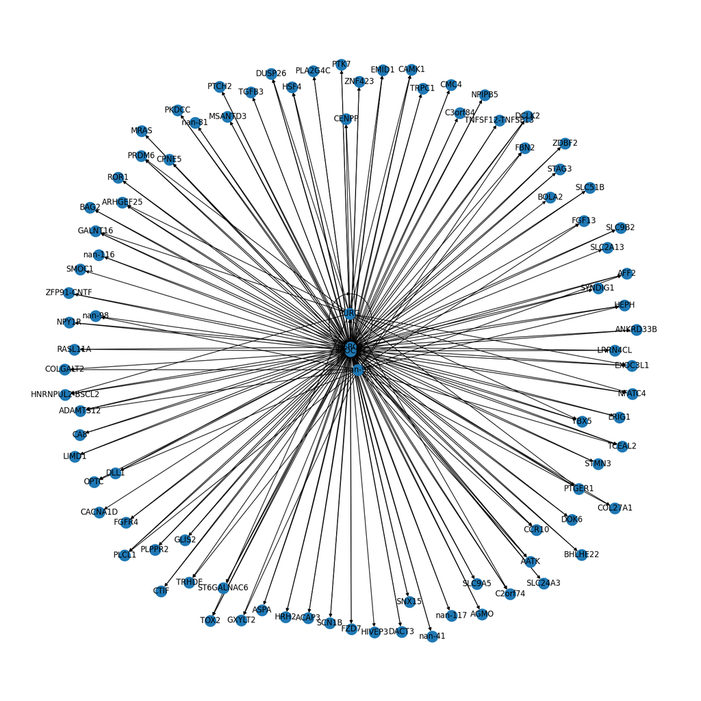

```python
# if you want to draw better looking networks
pnet = pnx.Network(notebook=True, cdn_resources="remote", directed=True)
pnet.from_nx(G)
# first_node = list(G.nodes)[-1]
# pnet.get_node(first_node)['color'] = "red"
pnet.save_graph("../figures/pyvis/grn_c_4.html")
```

# if you want to draw better looking networks pnet = pnx.Network(notebook=True, cdn_resources="remote", directed=True) pnet.from_nx(G) # first_node = list(G.nodes)[-1] # pnet.get_node(first_node)['color'] = "red" pnet.save_graph("../figures/pyvis/grn_c_4.html")

```python
# Assuming 'node_names' contains the list of gene names.
# Note: it seems with enrichr, one can only use one gene set at a time, choose accordingly
enr = gp.enrichr(
    gene_list=list(G.nodes),
    gene_sets=[
        "KEGG_2021_Human",
        "MSigDB_Hallmark_2020",
        "Reactome_2022",
        "Tabula_Sapiens",
        "WikiPathway_2023_Human",
        "TF_Perturbations_Followed_by_Expression",
        "Reactome",
        "PPI_Hub_Proteins",
        "OMIM_Disease",
        "GO_Molecular_Function_2023",
    ],
    organism="Human",  # change accordingly
    # description='pathway',
    # cutoff=0.08, # test dataset, use lower value for real case
    background=grn_c.var.symbol.tolist(),
)
enr.res2d.head(20)
```

# Assuming 'node_names' contains the list of gene names. # Note: it seems with enrichr, one can only use one gene set at a time, choose accordingly enr = gp.enrichr( gene_list=list(G.nodes), gene_sets=[ "KEGG_2021_Human", "MSigDB_Hallmark_2020", "Reactome_2022", "Tabula_Sapiens", "WikiPathway_2023_Human", "TF_Perturbations_Followed_by_Expression", "Reactome", "PPI_Hub_Proteins", "OMIM_Disease", "GO_Molecular_Function_2023", ], organism="Human", # change accordingly # description='pathway', # cutoff=0.08, # test dataset, use lower value for real case background=grn_c.var.symbol.tolist(), ) enr.res2d.head(20)

```
2024-07-25 18:31:53,534 [WARNING] Input library not found: Reactome. Skip
```

|  | Gene_set | Term | P-value | Adjusted P-value | Old P-value | Old adjusted P-value | Odds Ratio | Combined Score | Genes |
| --- | --- | --- | --- | --- | --- | --- | --- | --- | --- |
| 0 | GO_Molecular_Function_2023 | Solute:Potassium Antiporter Activity (GO:0022821) | 0.000523 | 0.050652 | 0 | 0 | inf | inf | SLC24A3;SLC9A5 |
| 1 | GO_Molecular_Function_2023 | Coreceptor Activity Involved In Wnt Signaling ... | 0.001547 | 0.050652 | 0 | 0 | 86.822222 | 561.890021 | PTK7;ROR1 |
| 2 | GO_Molecular_Function_2023 | Sodium Ion Transmembrane Transporter Activity ... | 0.001547 | 0.050652 | 0 | 0 | 86.822222 | 561.890021 | SLC9A5;SLC9B2 |
| 3 | GO_Molecular_Function_2023 | Calcium Ion Transmembrane Transporter Activity... | 0.001700 | 0.050652 | 0 | 0 | 16.432584 | 104.795452 | SLC24A3;TRPC1;CACNA1D |
| 4 | GO_Molecular_Function_2023 | Calcium-Dependent Phospholipid Binding (GO:000... | 0.003047 | 0.050652 | 0 | 0 | 43.400000 | 251.445478 | CPNE5;PLA2G4C |
| 5 | GO_Molecular_Function_2023 | Coreceptor Activity Involved In Wnt Signaling ... | 0.003047 | 0.050652 | 0 | 0 | 43.400000 | 251.445478 | PTK7;ROR1 |
| 6 | GO_Molecular_Function_2023 | Metal Cation:Proton Antiporter Activity (GO:00... | 0.003047 | 0.050652 | 0 | 0 | 43.400000 | 251.445478 | SLC9A5;SLC9B2 |
| 7 | GO_Molecular_Function_2023 | Sodium:Proton Antiporter Activity (GO:0015385) | 0.003047 | 0.050652 | 0 | 0 | 43.400000 | 251.445478 | SLC9A5;SLC9B2 |
| 8 | GO_Molecular_Function_2023 | Iron Ion Binding (GO:0005506) | 0.005002 | 0.070586 | 0 | 0 | 28.925926 | 153.247105 | HEPH;AGMO |
| 9 | GO_Molecular_Function_2023 | Calcium Channel Activity (GO:0005262) | 0.005307 | 0.070586 | 0 | 0 | 10.099395 | 52.907606 | SLC24A3;TRPC1;CACNA1D |
| 10 | GO_Molecular_Function_2023 | Wnt Receptor Activity (GO:0042813) | 0.007391 | 0.089364 | 0 | 0 | 21.688889 | 106.438022 | FZD7;ROR1 |
| 11 | GO_Molecular_Function_2023 | RNA Polymerase II-specific DNA-binding Transcr... | 0.010110 | 0.104284 | 0 | 0 | 7.715135 | 35.445265 | TBX5;DUSP26;DLL1 |
| 12 | GO_Molecular_Function_2023 | Phospholipase Activity (GO:0004620) | 0.010193 | 0.104284 | 0 | 0 | 17.346667 | 79.552387 | PLCL1;PLA2G4C |
| 13 | GO_Molecular_Function_2023 | Monoatomic Cation Channel Activity (GO:0005261) | 0.011601 | 0.110210 | 0 | 0 | 7.284644 | 32.465172 | SLC24A3;TRPC1;CACNA1D |
| 14 | GO_Molecular_Function_2023 | Sodium Channel Regulator Activity (GO:0017080) | 0.013389 | 0.118714 | 0 | 0 | 14.451852 | 62.335739 | FGF13;SCN1B |
| 15 | GO_Molecular_Function_2023 | RNA Polymerase II Cis-Regulatory Region Sequen... | 0.022992 | 0.139045 | 0 | 0 | 2.668376 | 10.066740 | HSF4;HIVEP3;BHLHE22;TBX5;ZNF423;NFATC4;GLIS2 |
| 16 | GO_Molecular_Function_2023 | Calcium:Sodium Antiporter Activity (GO:0005432) | 0.023000 | 0.139045 | 0 | 0 | inf | inf | SLC24A3 |
| 17 | GO_Molecular_Function_2023 | Potassium:Proton Antiporter Activity (GO:0015386) | 0.023000 | 0.139045 | 0 | 0 | inf | inf | SLC9A5 |
| 18 | GO_Molecular_Function_2023 | Xylosyltransferase Activity (GO:0042285) | 0.023000 | 0.139045 | 0 | 0 | inf | inf | GXYLT2 |
| 19 | GO_Molecular_Function_2023 | Tat Protein Binding (GO:0030957) | 0.023000 | 0.139045 | 0 | 0 | inf | inf | DLL1 |

```python
# we make a plot of the enrichment
enr.res2d.Term = enr.res2d.Term.str.split("(").str[0].str.split(",").str[0]
ax = dotplot(
    enr.res2d.replace([np.inf, -np.inf], 0).dropna(),
    column="Adjusted P-value",
    # title='normal fibro PAGE4',
    cmap=plt.cm.viridis,
    size=4,  # adjust dot size
    top_term=20,
    figsize=(4, 10),
    cutoff=0.25,
)
```

# we make a plot of the enrichment enr.res2d.Term = enr.res2d.Term.str.split("(").str[0].str.split(",").str[0] ax = dotplot( enr.res2d.replace([np.inf, -np.inf], 0).dropna(), column="Adjusted P-value", # title='normal fibro PAGE4', cmap=plt.cm.viridis, size=4, # adjust dot size top_term=20, figsize=(4, 10), cutoff=0.25, )

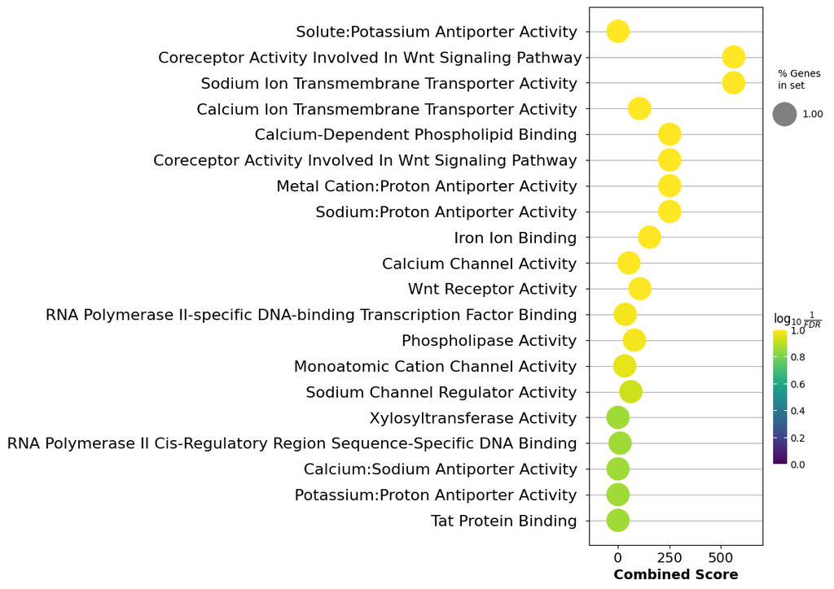

```python
G = grn_c.plot_subgraph(
    grn_c.var[grn_c.var["cluster_1.5"] == "5"].index.tolist(),
    only=80,
    interactive=False,
)  #
```

G = grn_c.plot_subgraph( grn_c.var[grn_c.var["cluster_1.5"] == "5"].index.tolist(), only=80, interactive=False, ) #

[output not shown]

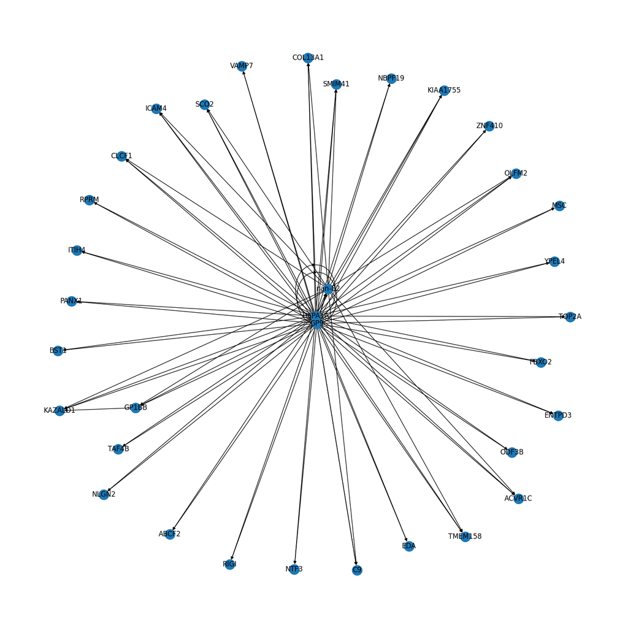

```python
pnet = pnx.Network(notebook=True, cdn_resources="remote", directed=True)
pnet.from_nx(G)
# first_node = list(G.nodes)[-1]
# pnet.get_node(first_node)['color'] = "red"
pnet.save_graph("../figures/pyvis/grn_c_5.html")
```

pnet = pnx.Network(notebook=True, cdn_resources="remote", directed=True) pnet.from_nx(G) # first_node = list(G.nodes)[-1] # pnet.get_node(first_node)['color'] = "red" pnet.save_graph("../figures/pyvis/grn_c_5.html")

```python
grn_c.var.loc["nan-82"]  # par of the Glycoside Hydrolase Family
```

grn_c.var.loc["nan-82"] # par of the Glycoside Hydrolase Family

```
uid                    4giyQrh7tkXI
symbol                       nan-82
ncbi_gene_ids
biotype              protein_coding
description           novel protein
synonyms
organism_id                       2
public_source_id                9.0
created_by_id                     1
mt                            False
ribo                          False
hb                            False
organism             NCBITaxon:9606
TFs                           False
ensembl_id          ENSG00000269590
centrality                      0.0
cluster_1.5                       5
Name: nan-82, dtype: object
```

```python
enr = gp.enrichr(
    gene_list=list(G.nodes),
    gene_sets=[
        "KEGG_2021_Human",
        "MSigDB_Hallmark_2020",
        "Reactome_2022",
        "Tabula_Sapiens",
        "WikiPathway_2023_Human",
        "TF_Perturbations_Followed_by_Expression",
        "Reactome",
        "PPI_Hub_Proteins",
        "OMIM_Disease",
        "GO_Molecular_Function_2023",
    ],
    organism="Human",  # change accordingly
    # description='pathway',
    # cutoff=0.08, # test dataset, use lower value for real case
    background=grn_c.var.symbol.tolist(),
)
enr.res2d.head(20)
```

enr = gp.enrichr( gene_list=list(G.nodes), gene_sets=[ "KEGG_2021_Human", "MSigDB_Hallmark_2020", "Reactome_2022", "Tabula_Sapiens", "WikiPathway_2023_Human", "TF_Perturbations_Followed_by_Expression", "Reactome", "PPI_Hub_Proteins", "OMIM_Disease", "GO_Molecular_Function_2023", ], organism="Human", # change accordingly # description='pathway', # cutoff=0.08, # test dataset, use lower value for real case background=grn_c.var.symbol.tolist(), ) enr.res2d.head(20)

```
2024-07-25 18:33:16,565 [WARNING] Input library not found: Reactome. Skip
```

|  | Gene_set | Term | P-value | Adjusted P-value | Old P-value | Old adjusted P-value | Odds Ratio | Combined Score | Genes |
| --- | --- | --- | --- | --- | --- | --- | --- | --- | --- |
| 0 | GO_Molecular_Function_2023 | Death Receptor Binding (GO:0005123) | 0.000416 | 0.028729 | 0 | 0 | 123.875000 | 964.236668 | EDA;NTF3 |
| 1 | GO_Molecular_Function_2023 | Purine Ribonucleoside Triphosphate Binding (GO... | 0.007050 | 0.073312 | 0 | 0 | 8.626100 | 42.739637 | ABCF2;RIGI;HSPA1A |
| 2 | GO_Molecular_Function_2023 | Receptor Ligand Activity (GO:0048018) | 0.007732 | 0.073312 | 0 | 0 | 5.742222 | 27.920829 | EDA;CLCF1;NTF3;HSPA1A |
| 3 | GO_Molecular_Function_2023 | Activin Receptor Activity (GO:0017002) | 0.008500 | 0.073312 | 0 | 0 | inf | inf | ACVR1C |
| 4 | GO_Molecular_Function_2023 | Gap Junction Hemi-Channel Activity (GO:0055077) | 0.008500 | 0.073312 | 0 | 0 | inf | inf | PANX1 |
| 5 | GO_Molecular_Function_2023 | NF-kappaB Binding (GO:0051059) | 0.008500 | 0.073312 | 0 | 0 | inf | inf | TAF4B |
| 6 | GO_Molecular_Function_2023 | Hydrolase Activity, Hydrolyzing N-glycosyl Com... | 0.008500 | 0.073312 | 0 | 0 | inf | inf | BST1 |
| 7 | GO_Molecular_Function_2023 | Ubiquitin-Protein Transferase Activator Activi... | 0.008500 | 0.073312 | 0 | 0 | inf | inf | RIGI |
| 8 | GO_Molecular_Function_2023 | DNA Binding, Bending (GO:0008301) | 0.016930 | 0.083096 | 0 | 0 | 120.151515 | 490.060134 | TOP2A |
| 9 | GO_Molecular_Function_2023 | Disordered Domain Specific Binding (GO:0097718) | 0.016930 | 0.083096 | 0 | 0 | 120.151515 | 490.060134 | HSPA1A |
| 10 | GO_Molecular_Function_2023 | UDP Phosphatase Activity (GO:0045134) | 0.016930 | 0.083096 | 0 | 0 | 120.151515 | 490.060134 | ENTPD3 |
| 11 | GO_Molecular_Function_2023 | GDP Phosphatase Activity (GO:0004382) | 0.016930 | 0.083096 | 0 | 0 | 120.151515 | 490.060134 | ENTPD3 |
| 12 | GO_Molecular_Function_2023 | Nucleoside Diphosphate Phosphatase Activity (G... | 0.016930 | 0.083096 | 0 | 0 | 120.151515 | 490.060134 | ENTPD3 |
| 13 | GO_Molecular_Function_2023 | ATP Binding (GO:0005524) | 0.017220 | 0.083096 | 0 | 0 | 11.204545 | 45.509349 | ABCF2;HSPA1A |
| 14 | GO_Molecular_Function_2023 | Ubiquitin Protein Ligase Binding (GO:0031625) | 0.020064 | 0.083096 | 0 | 0 | 10.265625 | 40.126707 | RIGI;HSPA1A |
| 15 | GO_Molecular_Function_2023 | Ubiquitin-Like Protein Ligase Binding (GO:0044... | 0.021555 | 0.083096 | 0 | 0 | 9.852500 | 37.805688 | RIGI;HSPA1A |
| 16 | GO_Molecular_Function_2023 | Growth Factor Activity (GO:0008083) | 0.023090 | 0.083096 | 0 | 0 | 9.471154 | 35.690549 | CLCF1;NTF3 |
| 17 | GO_Molecular_Function_2023 | Adenyl Ribonucleotide Binding (GO:0032559) | 0.024670 | 0.083096 | 0 | 0 | 9.118056 | 33.756535 | ABCF2;HSPA1A |
| 18 | GO_Molecular_Function_2023 | C3HC4-type RING Finger Domain Binding (GO:0055... | 0.025290 | 0.083096 | 0 | 0 | 60.060606 | 220.863728 | HSPA1A |
| 19 | GO_Molecular_Function_2023 | Ubiquitin Binding (GO:0043130) | 0.025290 | 0.083096 | 0 | 0 | 60.060606 | 220.863728 | TOP2A |

```python
enr.res2d.Term = enr.res2d.Term.str.split("(").str[0].str.split(",").str[0]
ax = dotplot(
    enr.res2d.replace([np.inf, -np.inf], 0).dropna(),
    column="Adjusted P-value",
    # title='normal fibro PAGE4',
    cmap=plt.cm.viridis,
    size=4,  # adjust dot size
    top_term=20,
    figsize=(4, 10),
    cutoff=0.25,
)
```

enr.res2d.Term = enr.res2d.Term.str.split("(").str[0].str.split(",").str[0] ax = dotplot( enr.res2d.replace([np.inf, -np.inf], 0).dropna(), column="Adjusted P-value", # title='normal fibro PAGE4', cmap=plt.cm.viridis, size=4, # adjust dot size top_term=20, figsize=(4, 10), cutoff=0.25, )

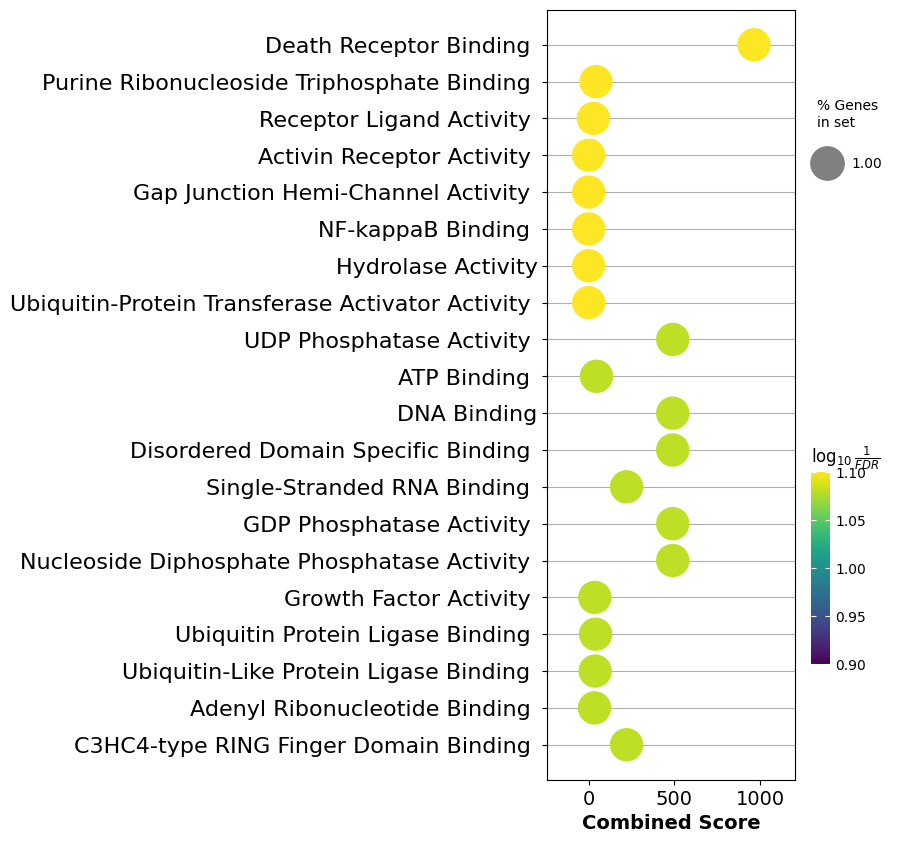

https://www.genecards.org/cgi-bin/carddisp.pl?gene=GSN

## 3.2 Normal version

```python
grn.var["cluster_1.5"].value_counts().head(10)
```

grn.var["cluster_1.5"].value_counts().head(10)

```
cluster_1.5
0     1620
1     1483
2      732
3      111
4       23
5        9
6        4
16       1
23       1
22       1
Name: count, dtype: int64
```

https://www.genecards.org/cgi-bin/carddisp.pl?gene=MYOC

```python
G = grn.plot_subgraph(
    grn.var[grn.var["cluster_1.5"] == "3"].index.tolist(), only=200, interactive=False
)
```

G = grn.plot_subgraph( grn.var[grn.var["cluster_1.5"] == "3"].index.tolist(), only=200, interactive=False )

[output not shown]

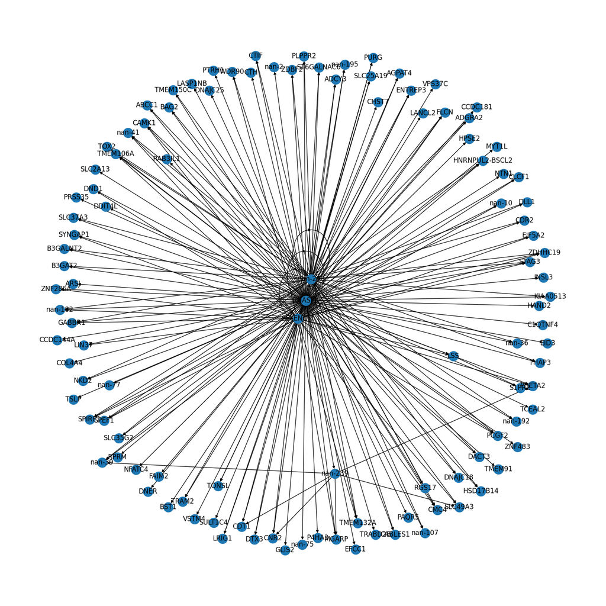

```python
pnet = pnx.Network(notebook=True, cdn_resources="remote", directed=True)
pnet.from_nx(G)
# first_node = list(G.nodes)[-1]
# pnet.get_node(first_node)['color'] = "red"
pnet.save_graph("../figures/pyvis/grn_3.html")
```

pnet = pnx.Network(notebook=True, cdn_resources="remote", directed=True) pnet.from_nx(G) # first_node = list(G.nodes)[-1] # pnet.get_node(first_node)['color'] = "red" pnet.save_graph("../figures/pyvis/grn_3.html")

```python
grn.var.loc["nan-259"]  # par of the Glycoside Hydrolase Family
```

grn.var.loc["nan-259"] # par of the Glycoside Hydrolase Family

```
uid                    62JAXxQNqtOd
symbol                      nan-259
ncbi_gene_ids                 83737
biotype              protein_coding
description           novel protein
synonyms
organism_id                       2
public_source_id                9.0
created_by_id                     1
mt                            False
ribo                          False
hb                            False
organism             NCBITaxon:9606
TFs                           False
ensembl_id          ENSG00000289720
centrality                      0.0
cluster_1.5                       3
Name: nan-259, dtype: object
```

```python
grn.get(grn.var[grn.var["cluster_1.5"] == "3"].index.tolist()).grn.sum(0).sort_values(
    ascending=False
).head(3)  ##.grn # selenom
```

grn.get(grn.var[grn.var["cluster_1.5"] == "3"].index.tolist()).grn.sum(0).sort_values( ascending=False ).head(3) ##.grn # selenom

```
symbol
RNASEK     0.942102
SELENOM    0.292933
nan-259    0.256140
dtype: float32
```

RNASEK acidifying the internal vesicle important in endocytosis# https://www.ncbi.nlm.nih.gov/pmc/articles/PMC10547866/ RNA phosphodiester bond hydrolysis --> hydrolisis pathway in the model and RNA transcription regulation

```python
# Assuming 'node_names' contains the list of gene names
enr = gp.enrichr(
    gene_list=list(G.nodes),
    gene_sets=[
        "KEGG_2021_Human",
        "MSigDB_Hallmark_2020",
        "Reactome_2022",
        "Tabula_Sapiens",
        "WikiPathway_2023_Human",
        "TF_Perturbations_Followed_by_Expression",
        "Reactome",
        "PPI_Hub_Proteins",
        "OMIM_Disease",
        "GO_Molecular_Function_2023",
    ],
    organism="Human",  # change accordingly
    # description='pathway',
    # cutoff=0.08, # test dataset, use lower value for real case
    background=grn.var.symbol.tolist(),
)
enr.res2d.head(20)
```

# Assuming 'node_names' contains the list of gene names enr = gp.enrichr( gene_list=list(G.nodes), gene_sets=[ "KEGG_2021_Human", "MSigDB_Hallmark_2020", "Reactome_2022", "Tabula_Sapiens", "WikiPathway_2023_Human", "TF_Perturbations_Followed_by_Expression", "Reactome", "PPI_Hub_Proteins", "OMIM_Disease", "GO_Molecular_Function_2023", ], organism="Human", # change accordingly # description='pathway', # cutoff=0.08, # test dataset, use lower value for real case background=grn.var.symbol.tolist(), ) enr.res2d.head(20)

```
2024-07-25 18:33:49,291 [WARNING] Input library not found: Reactome. Skip
```

|  | Gene_set | Term | P-value | Adjusted P-value | Old P-value | Old adjusted P-value | Odds Ratio | Combined Score | Genes |
| --- | --- | --- | --- | --- | --- | --- | --- | --- | --- |
| 0 | GO_Molecular_Function_2023 | Sulfotransferase Activity (GO:0008146) | 0.007252 | 0.123369 | 0 | 0 | 20.138462 | 99.212171 | CHST7;SULT1C4 |
| 1 | GO_Molecular_Function_2023 | RNA Polymerase II Transcription Regulatory Reg... | 0.007713 | 0.123369 | 0 | 0 | 3.386005 | 16.472449 | ZNF483;HAND2;NTN1;NFATC4;GLIS2;PURG;ZNF286A |
| 2 | GO_Molecular_Function_2023 | ATPase Binding (GO:0051117) | 0.013790 | 0.123369 | 0 | 0 | 13.415385 | 57.468682 | SLC2A13;NKD2 |
| 3 | GO_Molecular_Function_2023 | Chondroitin Sulfotransferase Activity (GO:0034... | 0.016750 | 0.123369 | 0 | 0 | inf | inf | CHST7 |
| 4 | GO_Molecular_Function_2023 | Peptidyl-Proline 4-Dioxygenase Activity (GO:00... | 0.016750 | 0.123369 | 0 | 0 | inf | inf | P4HA3 |
| 5 | GO_Molecular_Function_2023 | Aryl Sulfotransferase Activity (GO:0004062) | 0.016750 | 0.123369 | 0 | 0 | inf | inf | SULT1C4 |
| 6 | GO_Molecular_Function_2023 | Histone Reader Activity (GO:0140566) | 0.016750 | 0.123369 | 0 | 0 | inf | inf | TONSL |
| 7 | GO_Molecular_Function_2023 | Hydrolase Activity, Hydrolyzing N-glycosyl Com... | 0.016750 | 0.123369 | 0 | 0 | inf | inf | BST1 |
| 8 | GO_Molecular_Function_2023 | Tat Protein Binding (GO:0030957) | 0.016750 | 0.123369 | 0 | 0 | inf | inf | DLL1 |
| 9 | GO_Molecular_Function_2023 | WW Domain Binding (GO:0050699) | 0.016750 | 0.123369 | 0 | 0 | inf | inf | ENTREP3 |
| 10 | GO_Molecular_Function_2023 | RNA Polymerase II Cis-Regulatory Region Sequen... | 0.016754 | 0.123369 | 0 | 0 | 3.180050 | 13.003634 | ZNF483;HAND2;NTN1;NFATC4;GLIS2;ZNF286A |
| 11 | GO_Molecular_Function_2023 | DNA-binding Transcription Activator Activity, ... | 0.026719 | 0.134555 | 0 | 0 | 5.074219 | 18.380719 | HAND2;INSL3;GLIS2 |
| 12 | GO_Molecular_Function_2023 | Procollagen-Proline Dioxygenase Activity (GO:0... | 0.033223 | 0.134555 | 0 | 0 | 59.575758 | 202.825781 | P4HA3 |
| 13 | GO_Molecular_Function_2023 | N-acetylglucosamine 6-O-sulfotransferase Activ... | 0.033223 | 0.134555 | 0 | 0 | 59.575758 | 202.825781 | CHST7 |
| 14 | GO_Molecular_Function_2023 | ABC-type Xenobiotic Transporter Activity (GO:0... | 0.033223 | 0.134555 | 0 | 0 | 59.575758 | 202.825781 | ABCC1 |
| 15 | GO_Molecular_Function_2023 | alpha-N-acetylgalactosaminide Alpha-2,6-Sialyl... | 0.033223 | 0.134555 | 0 | 0 | 59.575758 | 202.825781 | ST6GALNAC6 |
| 16 | GO_Molecular_Function_2023 | miRNA Binding (GO:0035198) | 0.033223 | 0.134555 | 0 | 0 | 59.575758 | 202.825781 | DND1 |
| 17 | GO_Molecular_Function_2023 | Myosin Heavy Chain Binding (GO:0032036) | 0.033223 | 0.134555 | 0 | 0 | 59.575758 | 202.825781 | NKD2 |
| 18 | GO_Molecular_Function_2023 | Estradiol 17-Beta-Dehydrogenase [NAD(P)] Activ... | 0.033223 | 0.134555 | 0 | 0 | 59.575758 | 202.825781 | HSD17B14 |
| 19 | GO_Molecular_Function_2023 | Solute:Proton Symporter Activity (GO:0015295) | 0.033223 | 0.134555 | 0 | 0 | 59.575758 | 202.825781 | SLC2A13 |

```python
enr.res2d.Term = enr.res2d.Term.str.split("(").str[0].str.split(",").str[0].str[:50]
ax = dotplot(
    enr.res2d.replace([np.inf, -np.inf], 0).dropna(),
    column="Adjusted P-value",
    # title='normal fibro PAGE4',
    cmap=plt.cm.viridis,
    size=4,  # adjust dot size
    top_term=20,
    figsize=(4, 10),
    cutoff=0.25,
)
```

enr.res2d.Term = enr.res2d.Term.str.split("(").str[0].str.split(",").str[0].str[:50] ax = dotplot( enr.res2d.replace([np.inf, -np.inf], 0).dropna(), column="Adjusted P-value", # title='normal fibro PAGE4', cmap=plt.cm.viridis, size=4, # adjust dot size top_term=20, figsize=(4, 10), cutoff=0.25, )

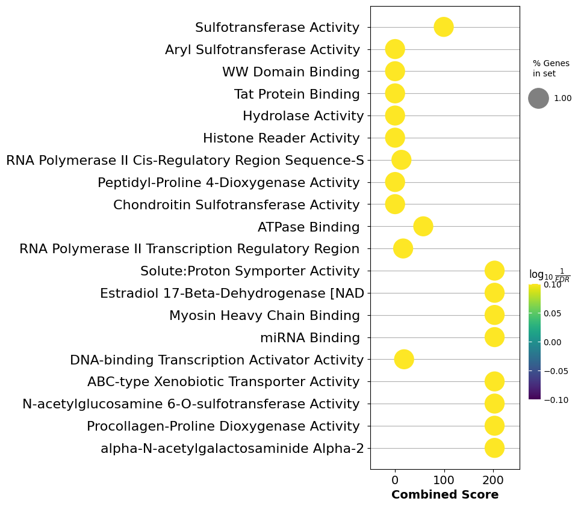

https://www.genecards.org/cgi-bin/carddisp.pl?gene=PTN

```python
G = grn.plot_subgraph(
    grn.var[grn.var["cluster_1.5"] == "4"].index.tolist(), only=80, interactive=False
)  #
```

G = grn.plot_subgraph( grn.var[grn.var["cluster_1.5"] == "4"].index.tolist(), only=80, interactive=False ) #

[output not shown]

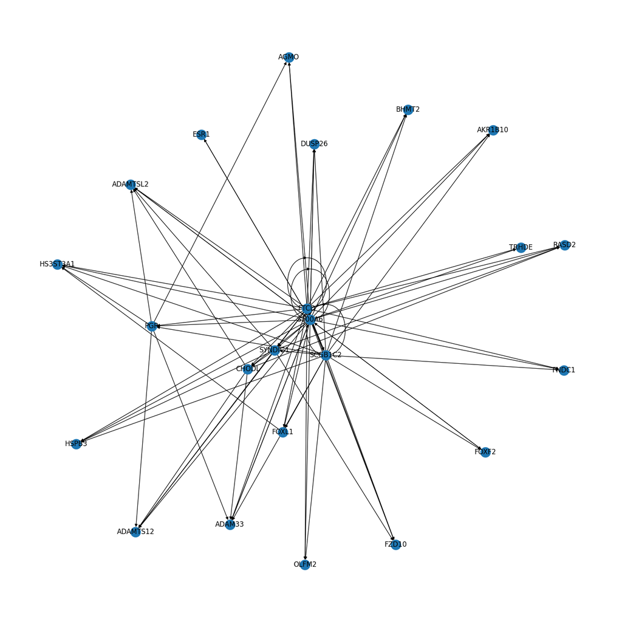

```python
pnet = pnx.Network(notebook=True, cdn_resources="remote", directed=True)
pnet.from_nx(G)
# first_node = list(G.nodes)[-1]
# pnet.get_node(first_node)['color'] = "red"
pnet.save_graph("../figures/pyvis/grn_4.html")
```

pnet = pnx.Network(notebook=True, cdn_resources="remote", directed=True) pnet.from_nx(G) # first_node = list(G.nodes)[-1] # pnet.get_node(first_node)['color'] = "red" pnet.save_graph("../figures/pyvis/grn_4.html")

```python
enr = gp.enrichr(
    gene_list=list(G.nodes),
    gene_sets=[
        "GO_Molecular_Function_2023",
        "MSigDB_Hallmark_2020",
        "Reactome_2022",
        "Tabula_Sapiens",
        "WikiPathway_2023_Human",
        "TF_Perturbations_Followed_by_Expression",
        "Reactome",
        "PPI_Hub_Proteins",
        "OMIM_Disease",
        "GO_Molecular_Function_2023",
    ],
    organism="Human",  # change accordingly
    # description='pathway',
    # cutoff=0.08, # test dataset, use lower value for real case
    background=grn.var.symbol.tolist(),
)
enr.res2d.head(20)
```

enr = gp.enrichr( gene_list=list(G.nodes), gene_sets=[ "GO_Molecular_Function_2023", "MSigDB_Hallmark_2020", "Reactome_2022", "Tabula_Sapiens", "WikiPathway_2023_Human", "TF_Perturbations_Followed_by_Expression", "Reactome", "PPI_Hub_Proteins", "OMIM_Disease", "GO_Molecular_Function_2023", ], organism="Human", # change accordingly # description='pathway', # cutoff=0.08, # test dataset, use lower value for real case background=grn.var.symbol.tolist(), ) enr.res2d.head(20)

```
2024-07-25 18:34:27,578 [WARNING] Input library not found: Reactome. Skip
```

|  | Gene_set | Term | P-value | Adjusted P-value | Old P-value | Old adjusted P-value | Odds Ratio | Combined Score | Genes |
| --- | --- | --- | --- | --- | --- | --- | --- | --- | --- |
| 0 | GO_Molecular_Function_2023 | RNA Polymerase II General Transcription Initia... | 0.000032 | 0.000933 | 0 | 0 | inf | inf | FOXF2;ESR1 |
| 1 | GO_Molecular_Function_2023 | Estrogen Response Element Binding (GO:0034056) | 0.000032 | 0.000933 | 0 | 0 | inf | inf | PGR;ESR1 |
| 2 | GO_Molecular_Function_2023 | General Transcription Initiation Factor Bindin... | 0.000095 | 0.001860 | 0 | 0 | 378.666667 | 3508.819727 | FOXF2;ESR1 |
| 3 | GO_Molecular_Function_2023 | Transcription Coactivator Binding (GO:0001223) | 0.000188 | 0.002780 | 0 | 0 | 189.285714 | 1623.428489 | PGR;ESR1 |
| 4 | GO_Molecular_Function_2023 | Transition Metal Ion Binding (GO:0046914) | 0.000446 | 0.005263 | 0 | 0 | 13.515099 | 104.272240 | BHMT2;AGMO;ADAM33;TRHDE |
| 5 | GO_Molecular_Function_2023 | Metalloendopeptidase Activity (GO:0004222) | 0.000551 | 0.005414 | 0 | 0 | 22.794231 | 171.058857 | ADAMTSL2;ADAM33;ADAMTS12 |
| 6 | GO_Molecular_Function_2023 | Metallopeptidase Activity (GO:0008237) | 0.000672 | 0.005666 | 0 | 0 | 21.155357 | 154.536591 | ADAMTSL2;ADAM33;ADAMTS12 |
| 7 | GO_Molecular_Function_2023 | Transcription Coregulator Binding (GO:0001221) | 0.001111 | 0.008195 | 0 | 0 | 54.013605 | 367.419603 | PGR;ESR1 |
| 8 | GO_Molecular_Function_2023 | DNA-binding Transcription Activator Activity, ... | 0.001429 | 0.009365 | 0 | 0 | 15.972973 | 104.640056 | FOXF2;PGR;ESR1 |
| 9 | GO_Molecular_Function_2023 | ATPase Binding (GO:0051117) | 0.002016 | 0.011893 | 0 | 0 | 37.780952 | 234.495632 | PGR;ESR1 |
| 10 | GO_Molecular_Function_2023 | Zinc Ion Binding (GO:0008270) | 0.002284 | 0.012250 | 0 | 0 | 13.407955 | 81.545835 | BHMT2;ADAM33;TRHDE |
| 11 | GO_Molecular_Function_2023 | Cis-Regulatory Region Sequence-Specific DNA Bi... | 0.004517 | 0.021203 | 0 | 0 | 6.945569 | 37.504924 | FOXF2;PGR;FOXL1;ESR1 |
| 12 | GO_Molecular_Function_2023 | RNA Polymerase II Cis-Regulatory Region Sequen... | 0.005523 | 0.021203 | 0 | 0 | 6.541596 | 34.009122 | FOXF2;PGR;FOXL1;ESR1 |
| 13 | GO_Molecular_Function_2023 | DNA Binding, Bending (GO:0008301) | 0.005750 | 0.021203 | 0 | 0 | inf | inf | FOXL1 |
| 14 | GO_Molecular_Function_2023 | TBP-class Protein Binding (GO:0017025) | 0.005750 | 0.021203 | 0 | 0 | inf | inf | ESR1 |
| 15 | GO_Molecular_Function_2023 | [Heparan Sulfate]-Glucosamine 3-Sulfotransfera... | 0.005750 | 0.021203 | 0 | 0 | inf | inf | HS3ST3A1 |
| 16 | GO_Molecular_Function_2023 | RNA Polymerase II Transcription Regulatory Reg... | 0.008164 | 0.028333 | 0 | 0 | 5.812950 | 27.949028 | FOXF2;PGR;FOXL1;ESR1 |
| 17 | GO_Molecular_Function_2023 | Endopeptidase Activity (GO:0004175) | 0.008882 | 0.028593 | 0 | 0 | 8.021918 | 37.893119 | ADAMTSL2;ADAM33;ADAMTS12 |
| 18 | GO_Molecular_Function_2023 | DNA Binding (GO:0003677) | 0.009208 | 0.028593 | 0 | 0 | 7.911486 | 37.086673 | FOXF2;PGR;FOXL1 |
| 19 | GO_Molecular_Function_2023 | Heparan Sulfate Sulfotransferase Activity (GO:... | 0.011468 | 0.030756 | 0 | 0 | 180.727273 | 807.520606 | HS3ST3A1 |

```python
enr.res2d.Term = enr.res2d.Term.str.split("(").str[0].str.split(",").str[0].str[:50]
ax = dotplot(
    enr.res2d.replace([np.inf, -np.inf], 0).dropna(),
    column="Adjusted P-value",
    # title='normal fibro PAGE4',
    cmap=plt.cm.viridis,
    size=4,  # adjust dot size
    top_term=20,
    figsize=(4, 10),
    cutoff=0.25,
)
```

enr.res2d.Term = enr.res2d.Term.str.split("(").str[0].str.split(",").str[0].str[:50] ax = dotplot( enr.res2d.replace([np.inf, -np.inf], 0).dropna(), column="Adjusted P-value", # title='normal fibro PAGE4', cmap=plt.cm.viridis, size=4, # adjust dot size top_term=20, figsize=(4, 10), cutoff=0.25, )

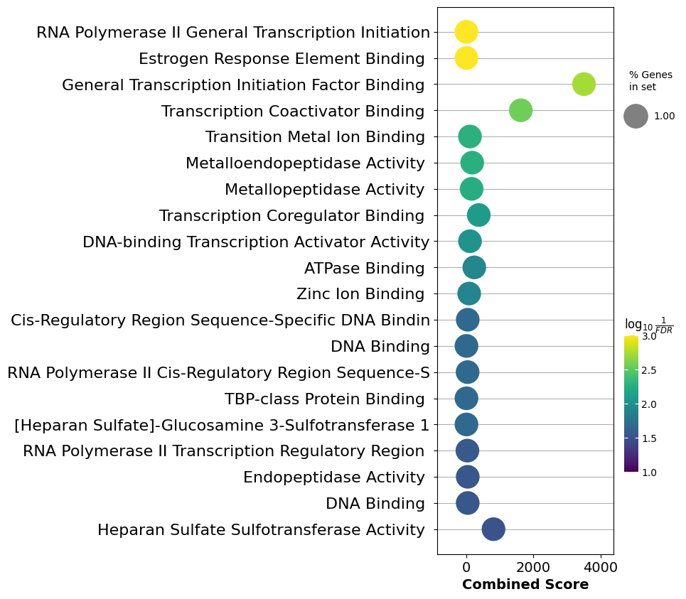

# 4. Differential Gene - Gene connections

- look at the connections of some key TFs in here
- do GSEA over these connections
- compare the connections of these same TFs for both conditions

```python
G = grn_c.plot_subgraph("PAGE4", only=100, max_genes=40, interactive=False)  #
```

G = grn_c.plot_subgraph("PAGE4", only=100, max_genes=40, interactive=False) #

[output not shown]

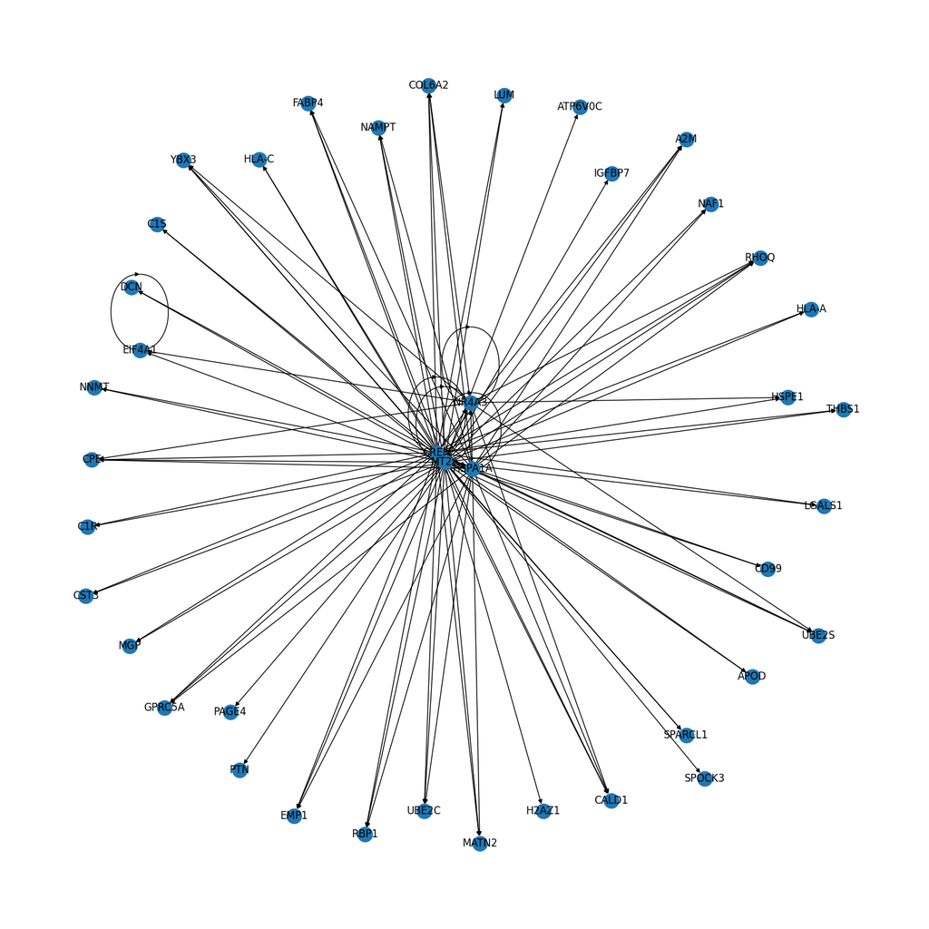

```python
pnet = pnx.Network(notebook=True, cdn_resources="remote", directed=True)
pnet.from_nx(G)
first_node = list(G.nodes)[-1]
pnet.get_node(first_node)["color"] = "red"
pnet.save_graph("../figures/pyvis/grn_c_PAGE4.html")
```

pnet = pnx.Network(notebook=True, cdn_resources="remote", directed=True) pnet.from_nx(G) first_node = list(G.nodes)[-1] pnet.get_node(first_node)["color"] = "red" pnet.save_graph("../figures/pyvis/grn_c_PAGE4.html")

```python
# Assuming 'node_names' contains the list of gene names
enr = gp.enrichr(
    gene_list=list(G.nodes),
    gene_sets=[
        #'KEGG_2021_Human',
        #'MSigDB_Hallmark_2020',
        #'Reactome_2022',
        #'Tabula_Sapiens',
        "WikiPathway_2023_Human",  #'TF_Perturbations_Followed_by_Expression',
        #'PPI_Hub_Proteins',
        #'OMIM_Disease',
        #'GO_Molecular_Function_2023'
    ],
    organism="Human",  # change accordingly
    # description='pathway',
    # cutoff=0.02, # test dataset, use lower value for real case
    background=grn.var.symbol.tolist(),
)
enr.res2d.head(10)
enr.res2d.Term = (
    enr.res2d.Term.str.split("(")
    .str[0]
    .str.split("R-HSA")
    .str[0]
    .str.split(" WP")
    .str[0]
    .str[:50]
)
ax = dotplot(
    enr.res2d.replace([np.inf, -np.inf], 0).dropna(),
    column="Adjusted P-value",
    title="normal fibro PAGE4",
    cmap=plt.cm.viridis,
    size=4,  # adjust dot size
    top_term=20,
    figsize=(4, 10),
    cutoff=0.25,
)
```

# Assuming 'node_names' contains the list of gene names enr = gp.enrichr( gene_list=list(G.nodes), gene_sets=[ #'KEGG_2021_Human', #'MSigDB_Hallmark_2020', #'Reactome_2022', #'Tabula_Sapiens', "WikiPathway_2023_Human", #'TF_Perturbations_Followed_by_Expression', #'PPI_Hub_Proteins', #'OMIM_Disease', #'GO_Molecular_Function_2023' ], organism="Human", # change accordingly # description='pathway', # cutoff=0.02, # test dataset, use lower value for real case background=grn.var.symbol.tolist(), ) enr.res2d.head(10) enr.res2d.Term = ( enr.res2d.Term.str.split("(") .str[0] .str.split("R-HSA") .str[0] .str.split(" WP") .str[0] .str[:50] ) ax = dotplot( enr.res2d.replace([np.inf, -np.inf], 0).dropna(), column="Adjusted P-value", title="normal fibro PAGE4", cmap=plt.cm.viridis, size=4, # adjust dot size top_term=20, figsize=(4, 10), cutoff=0.25, )

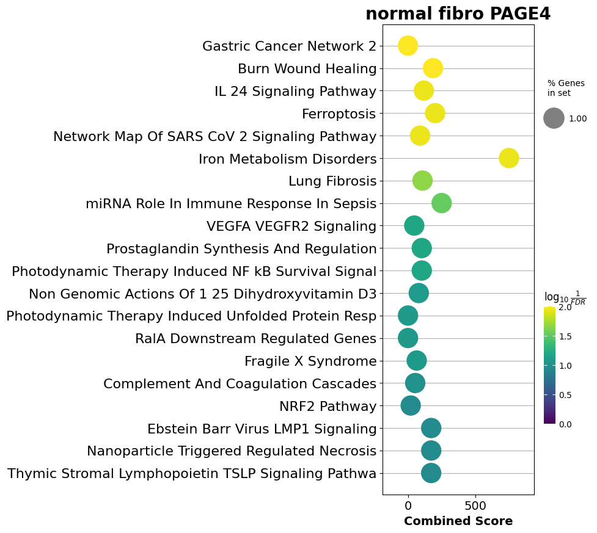

```python
enr.res2d.Term = enr.res2d.Term.str.split("(").str[0]
ax = dotplot(
    enr.res2d.replace([np.inf, -np.inf], 0).dropna(),
    column="Adjusted P-value",
    title="normal fibro PAGE4",
    cmap=plt.cm.viridis,
    size=4,  # adjust dot size
    figsize=(4, 5),
    cutoff=0.25,
)
```

enr.res2d.Term = enr.res2d.Term.str.split("(").str[0] ax = dotplot( enr.res2d.replace([np.inf, -np.inf], 0).dropna(), column="Adjusted P-value", title="normal fibro PAGE4", cmap=plt.cm.viridis, size=4, # adjust dot size figsize=(4, 5), cutoff=0.25, )

[figure not shown]

```python
G = grn.plot_subgraph("PAGE4", only=100, max_genes=40, interactive=False)
```

G = grn.plot_subgraph("PAGE4", only=100, max_genes=40, interactive=False)

[output not shown]

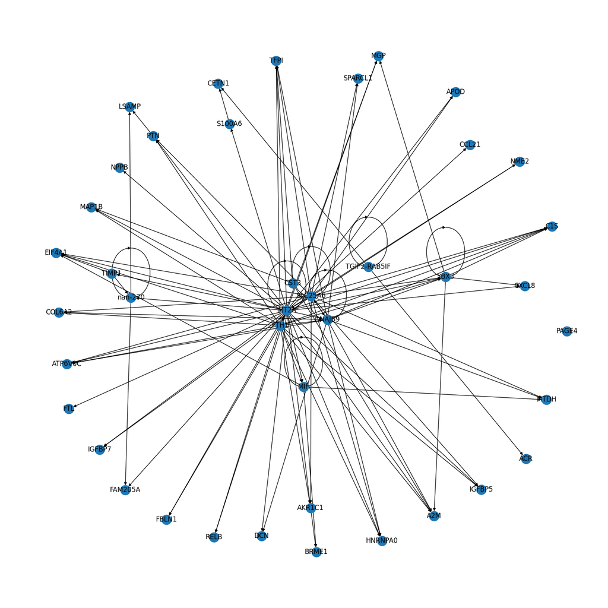

```python
pnet = pnx.Network(notebook=True, cdn_resources="remote", directed=True)
pnet.from_nx(G)
first_node = list(G.nodes)[-1]
pnet.get_node(first_node)["color"] = "red"
pnet.save_graph("../figures/pyvis/grn_PAGE4.html")
```

pnet = pnx.Network(notebook=True, cdn_resources="remote", directed=True) pnet.from_nx(G) first_node = list(G.nodes)[-1] pnet.get_node(first_node)["color"] = "red" pnet.save_graph("../figures/pyvis/grn_PAGE4.html")

```python
# Assuming 'node_names' contains the list of gene names
enr = gp.enrichr(
    gene_list=list(G.nodes),
    gene_sets=[
        "KEGG_2021_Human",
        #'MSigDB_Hallmark_2020',
        #'Reactome_2022',
        #'Tabula_Sapiens',
        #'WikiPathway_2023_Human',
        # 'TF_Perturbations_Followed_by_Expression',
        # 'Reactome',
        #'PPI_Hub_Proteins',
        #'OMIM_Disease',
        "GO_Molecular_Function_2023",
    ],
    organism="Human",  # change accordingly
    # description='pathway',
    # cutoff=0.02, # test dataset, use lower value for real case
    background=grn.var.symbol.tolist(),
)
enr.res2d.head(20)
```

# Assuming 'node_names' contains the list of gene names enr = gp.enrichr( gene_list=list(G.nodes), gene_sets=[ "KEGG_2021_Human", #'MSigDB_Hallmark_2020', #'Reactome_2022', #'Tabula_Sapiens', #'WikiPathway_2023_Human', # 'TF_Perturbations_Followed_by_Expression', # 'Reactome', #'PPI_Hub_Proteins', #'OMIM_Disease', "GO_Molecular_Function_2023", ], organism="Human", # change accordingly # description='pathway', # cutoff=0.02, # test dataset, use lower value for real case background=grn.var.symbol.tolist(), ) enr.res2d.head(20)

|  | Gene_set | Term | P-value | Adjusted P-value | Old P-value | Old adjusted P-value | Odds Ratio | Combined Score | Genes |
| --- | --- | --- | --- | --- | --- | --- | --- | --- | --- |
| 0 | GO_Molecular_Function_2023 | Peptidase Inhibitor Activity (GO:0030414) | 0.000020 | 0.001566 | 0 | 0 | 104.105263 | 1128.623016 | CST3;TIMP1;TFPI |
| 1 | GO_Molecular_Function_2023 | Transition Metal Ion Binding (GO:0046914) | 0.000463 | 0.016191 | 0 | 0 | 9.025463 | 69.301557 | ACR;MT2A;FTH1;TIMP1;FTL |
| 2 | GO_Molecular_Function_2023 | Double-Stranded RNA Binding (GO:0003725) | 0.000607 | 0.016191 | 0 | 0 | 101.461538 | 751.496153 | EIF4A1;MTDH |
| 3 | GO_Molecular_Function_2023 | Endopeptidase Inhibitor Activity (GO:0004866) | 0.001010 | 0.019977 | 0 | 0 | 18.306502 | 126.278211 | CST3;TIMP1;TFPI |
| 4 | GO_Molecular_Function_2023 | Endopeptidase Regulator Activity (GO:0061135) | 0.001498 | 0.019977 | 0 | 0 | 50.705128 | 329.757829 | CST3;TFPI |
| 5 | GO_Molecular_Function_2023 | Ferrous Iron Binding (GO:0008198) | 0.001498 | 0.019977 | 0 | 0 | 50.705128 | 329.757829 | FTH1;FTL |
| 6 | GO_Molecular_Function_2023 | Protease Binding (GO:0002020) | 0.002465 | 0.027606 | 0 | 0 | 12.944079 | 77.736001 | CST3;ACR;TIMP1 |
| 7 | GO_Molecular_Function_2023 | Iron Ion Binding (GO:0005506) | 0.002761 | 0.027606 | 0 | 0 | 33.786325 | 199.079000 | FTH1;FTL |
| 8 | GO_Molecular_Function_2023 | Calcium Ion Binding (GO:0005509) | 0.003252 | 0.028910 | 0 | 0 | 7.400664 | 42.393777 | CETN1;S100A6;SPARCL1;FBLN1 |
| 9 | GO_Molecular_Function_2023 | Kinase Binding (GO:0019900) | 0.005211 | 0.038377 | 0 | 0 | 9.688322 | 50.930509 | PTN;RELB;HNRNPA0 |
| 10 | GO_Molecular_Function_2023 | RNA Binding (GO:0003723) | 0.005277 | 0.038377 | 0 | 0 | 5.000000 | 26.222182 | EIF4A1;YBX3;DCN;MTDH;HNRNPA0 |
| 11 | GO_Molecular_Function_2023 | Chemokine Activity (GO:0008009) | 0.007445 | 0.039047 | 0 | 0 | 18.405594 | 90.191859 | CXCL8;CCL21 |
| 12 | GO_Molecular_Function_2023 | Chemokine Receptor Binding (GO:0042379) | 0.007445 | 0.039047 | 0 | 0 | 18.405594 | 90.191859 | CXCL8;CCL21 |
| 13 | GO_Molecular_Function_2023 | Metal Ion Binding (GO:0046872) | 0.008569 | 0.039047 | 0 | 0 | 5.523471 | 26.289761 | CETN1;S100A6;SPARCL1;FBLN1 |
| 14 | GO_Molecular_Function_2023 | Protein Kinase Binding (GO:0019901) | 0.009285 | 0.039047 | 0 | 0 | 7.734868 | 36.193807 | PTN;RELB;HNRNPA0 |
| 15 | GO_Molecular_Function_2023 | mRNA 3'-UTR Binding (GO:0003730) | 0.009893 | 0.039047 | 0 | 0 | 15.566075 | 71.852090 | YBX3;HNRNPA0 |
| 16 | GO_Molecular_Function_2023 | NF-kappaB Binding (GO:0051059) | 0.010250 | 0.039047 | 0 | 0 | inf | inf | MTDH |
| 17 | GO_Molecular_Function_2023 | Phosphatase Inhibitor Activity (GO:0019212) | 0.010250 | 0.039047 | 0 | 0 | inf | inf | PTN |
| 18 | GO_Molecular_Function_2023 | Phosphotransferase Activity, Phosphate Group A... | 0.010250 | 0.039047 | 0 | 0 | inf | inf | NME2 |
| 19 | GO_Molecular_Function_2023 | Nucleobase-Containing Compound Kinase Activity... | 0.010250 | 0.039047 | 0 | 0 | inf | inf | NME2 |

```python
enr.res2d.Term = enr.res2d.Term.str.split("(").str[0]
ax = dotplot(
    enr.res2d.replace([np.inf, -np.inf], 0).dropna(),
    column="Adjusted P-value",
    title="normal fibro PAGE4",
    cmap=plt.cm.viridis,
    size=4,  # adjust dot size
    figsize=(4, 5),
    cutoff=0.25,
)
```

enr.res2d.Term = enr.res2d.Term.str.split("(").str[0] ax = dotplot( enr.res2d.replace([np.inf, -np.inf], 0).dropna(), column="Adjusted P-value", title="normal fibro PAGE4", cmap=plt.cm.viridis, size=4, # adjust dot size figsize=(4, 5), cutoff=0.25, )

[figure not shown]

# 5. Using classification

Here we used the network given by the mean of all heads in our scPRINT model. We could also use other scPRINT versions to see if the results are consistent. but we could also use the classification mechanism presented in our [manuscript](https://www.biorxiv.org/content/10.1101/2024.07.29.605556v1) and other notebooks to get to possibly more specialized networks.

```python
grn_normal = grn_inferer(layer=list(range(model.nlayers))[:], cell_type="naive B cell")
grn_normal, m, omni_cls = train_classifier(
    grn_normal, C=0.5, train_size=0.9, class_weight={1: 200, 0: 1}, shuffle=True
)
```

grn_normal = grn_inferer(layer=list(range(model.nlayers))[:], cell_type="naive B cell") grn_normal, m, omni_cls = train_classifier( grn_normal, C=0.5, train_size=0.9, class_weight={1: 200, 0: 1}, shuffle=True )

```
number of expressed genes in this cell type: 16801
```

```
LOCAL_RANK: 0 - CUDA_VISIBLE_DEVICES: [0]
```

```
Predicting: 0it [00:00, ?it/s]
```

```
true elem 2115 ...
doing regression....
metrics {'used_heads': 25, 'precision': 0.0, 'random_precision': 0.0006433550820644942, 'recall': 0.0, 'predicted_true': 177.0, 'number_of_true': 219.0, 'epr': 0.0}
```

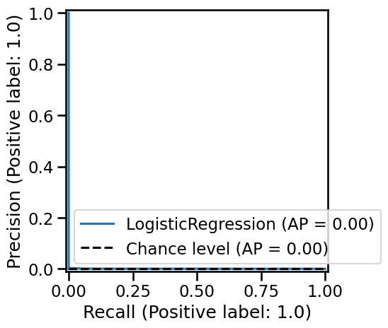

```python
# highlight differential links on genes that are expressed in both
grn_normal.varp["all"] = grn_normal.varp["GRN"].copy()
grn_normal.varp["GRN"] = grn_normal.varp["classified"]
```

# highlight differential links on genes that are expressed in both grn_normal.varp["all"] = grn_normal.varp["GRN"].copy() grn_normal.varp["GRN"] = grn_normal.varp["classified"]

# Notes on findings and their relation to the literature

CAV1-expressing CAFs contribute to invasion and metastasis in breast cancer24 loss of caveolin1 (CAV1) is found in metabolically reprogrammed CAFs that promote tumorigenesis

discoidin domain-containing receptor 2 (DDR2)21 and integrin α11β122, have emerged to identify CAFs in the context of a specific TME https://www.nature.com/articles/s12276-023-01013-0

normal fibroblast populations marked by the expression of Gli1 and Hoxb6

CAFs, remain perpetually activated with a high capacity for ECM synthesis and microenvironmental remodeling, leading to stromal desmoplasia, a phenomenon characterized by increased deposition of ECM components in tumors. In this regard, CAFs share many basic characteristics, such as a secretory phenotype and capacity to synthesize ECM components, with fibroblasts found in nonmalignant tissue fibrosis. Therefore, the classic markers found to be expressed in fibroblasts, including α-SMA, vimentin, desmin, fibroblast-specific protein 1 (FSP1; also known as S100A4)

Fibrogenesis is part of a normal protective response to tissue injury that can become irreversible and progressive, leading to fatal diseases. Senescent cells are a main driver of fibrotic diseases through their secretome, known as senescence-associated secretory phenotype (SASP) CAFs (vCAFs), cycling CAFs (cCAFs), and developmental CAFs (dCAFs)

The stem-like ‘universal’ type of fibroblast cell, marked by expression of peptidase inhibitor 16 (Pi16) and Col15a, found in the steady state across tissues, activated fibroblasts, as observed by the development of LRRC15+ CAFs in PDAC.

. SOCS1: Suppressor of cytokine signaling; STAT3: Signal transducer and activator of transcription 3; LDH: Lactate dehydrogenase; PYCR1: pyrroline-5-carboxylate reductase

senescence, and multiple types of fibrotic diseases in mice and humans are characterized by the accumulation of iron. https://www.nature.com/articles/s42255-023-00928-2

Current evidence indicate that cancer-associated fibroblasts (CAFs) play an important role in prostate cancer (PCa) development and progression. playing a role in invasion.

NDRG2, TSPAN1, PTN, APOE, OR51E2, P4HB, STEAP1 and ABCC4 were used to construct molecular subtypes and CAF-related gene prognostic index (CRGPI)

Studies on the role of STEAP1, OR51E2, PTN, ABCC4, NDRG2 have been relatively in-depth. For instance, STEAP1 is all-called six-transmembrane epithelial antigen of the prostate 1, which belongs to a family of metalloproteinases involved in iron and copper homeostasis and other cellular processes37. STEAP1 is overexpressed on the plasma membrane of PCa cells and is associated with PCa invasiveness and metastasis50. The possible mechanism of STEAP1 promoting tumor proliferation and metastasis is by acting as a channel for small molecules that are involved in intercellular communication OR51E2 perhaps could be used as one of the biomarkers for PCa53,54,55,56 https://www.nature.com/articles/s41598-023-36125-0#Sec11

The protein encoded by ABCC4 is a member of the superfamily of ATP-binding cassette (ABC) transporters, which is also called multidrug resistance protein 4 (MRP4)64. MRP4 was reported to be associated with drug resistance of PCa in many studies65,66,67

PRRX1, OSR1, FOXD1, HOXC4,LHX9, TBX3 and TWIST2, targeted five or more TFs inthe fibroblast TRN. This influential-set explained 62.5% ofthe total number of regulatory edges and they collectivelytargeted 15 out of 18 TFs represented in the network. Upona closer examination of the fibroblastic network, the inter-actions among OSR1–PRRX1–TWIST2 were notably co-ordinated, regulating one another in both directions https://www.researchgate.net/publication/264633205_A_transient_disruption_of_fibroblastic_transcriptional_regulatory_network_facilitates_trans-differentiation

FGF receptors are important in PCa initiation and progression. These endocrine FGFs require alpha-Klotho (KL) and/or beta-Klotho (KLB), two related single-pass transmembrane proteins restricted in their tissue distribution. FGF19 is expressed in primary and metastatic PCa tissues where it functions as an autocrine growth factor. https://www.e-cancer.fr/Professionnels-de-sante/Veille-bibliographique/Nota-Bene-Cancer/NBC-174/The-endocrine-fibroblast-growth-factor-FGF19-promotes-prostate-cancer-progression

• Prostate cancer stroma contains diverse populations of fibroblasts. • Carcinoma associated fibroblasts can promote prostate carcinogenesis. • Interaction among fibroblast subsets modulate stromal-epithelial paracrine signaling. The stroma in the normal prostate is predominantly composed of smooth muscle cells while in cancer this is partially replaced by fibroblasts and myofibroblasts6. These fibroblastic cells are responsible for collagen and extracellular matrix (ECM) deposition, changing local organ stiffness

iCAF, myCAF, apCAF

It has been shown that SDF-1/CXCL12, secreted by CAF, acts via TGFβ–mediated upregulation of CXCR4 in epithelial cells to activate Akt signaling associated with tumorigenesis. Overexpression of SDF-1/CXCL12 and TGFβ1 in benign human prostate fibroblasts has been shown to induce malignant transformation of benign prostate epithelial cells and formation of highly invasive tumors in vivo

increased cadherin 2 (CDH2) mRNA expression in LNCaP cells

Upregulation of DNA methyltransferases (DNMT) consistent with aberrant promoter hypermethylation of tumor-suppressor genes in multiple cancer types including PCa has been reported

https://www.ncbi.nlm.nih.gov/pmc/articles/PMC8788937/#:~:text=The%20stroma%20in%20the%20normal,deposition%2C%20changing%20local%20organ%20stiffness.

CD10 and GPR77 can define a human CAF subset that sustains cancer stemness

Fibroblasts are also fundamental for inducing angiogenesis by secreting angiogenic factors such as vascular endothelial growth factor (VEGF) and matrix proteins Epithelial cells release TGFβ ligands, Kallikrein-related peptidase-4 (KLK4), CAFs are characterized by molecular markers that are upregulated compared to normal fibroblasts, such as fibroblast activation protein (FAP), PDGFR-β, fibroblast-specific protein-1 (FSP-1) (also known as S100A4)

ACTA2 α-smooth actin (α-SMA) Upregulated RT-qPCR, IHC on tissue microarrays [42,43] ASPN Asporin Upregulated Tag-based RNA profiling, microarray profiling, IHC, RT-qPCR [38,44,45] CAV1 Caveolin-1 Downregulated Tag profiling, IHC, RT-qPCR [38] COL1A1 Collagen Type-I Upregulated RT-qPCR, IHC [42,43] CXCL12 Stromal cell-derived factor 1 (SDF1)/ (C-X-C motif chemokine ligand 12 (CXCL12) Upregulated Tag-profiling, RT-qPCR, ELISA [38,46] FAP Fibroblast activation protein Upregulated IHC [42] FGF2, FGF7, FGF10 Fibroblast growth factor-2/-7/-10 Upregulated RT-qPCR, Western Blot, IHC [43,47,48] FN1 Fibronectin Upregulated Tag profiling, IHC, RT-qPCR [38] ITGA1 Integrin-α1 (CD49a) Upregulated IHC [49] OGN Osteoglycin Upregulated Tag-profiling, IHC, RT-qPCR [38] PDGFRB Platelet-derived growth factor receptor β Upregulated Microarray profiling [44,50] POSTN Periostin Upregulated Microarray profiling, IHC [44] S100A4 Fibroblast-specific protein 1 (FSP1)/S100 Calcium Binding Protein A4 (S100A4) Upregulated Immunofluorescence, RT-qPCR, Western Blot [51,52,53] S100A6 S100 Calcium Binding Protein A6 Downregulated Tag profiling, IHC, RT-qPCR [38] SPARC Secreted Protein Acidic and Cysteine Rich Up/downregulated Microarray profiling, Tag-profiling [38,44] STC1 Stanniocalcin 1 Downregulated Tag profiling, IHC, RT-qPCR [38] THY1 Cluster of differentiation 90 (CD90) antigen Upregulated IHC [54] TNC Tenascin C Upregulated RT-qPCR, IHC [42,43] VIM Vimentin Upregulated IHC

Benign prostatic hyperplasia (BPH) is a non-malignant growth of the prostate, typically occurring in older men with an occurrence of 80–90% of men in their 70s BPH develops in the transition zone differently from PCa foci, which usually develop in the peripheral zone

ESR1= . Here we studied the role of CAF estrogen receptor alpha (ERα) and found that it could protect against PCa invasion. ERα could function through a CAF–epithelial interaction via selectively upregulating thrombospondin 2 (Thbs2) and downregulating matrix metalloproteinase 3 (MMP3) at the protein and messenger RNA levels https://academic.oup.com/carcin/article/35/6/1301/449417

ACTA2: we found that “reactive CAFs” induce shear resistance to prostate tumor cells via intercellular contact and soluble derived factors. The reactive CAFs showed higher expression of α-smooth muscle actin (α-SMA) and fibroblast activation protein (FAP) compared to differentiated CAFs https://www.oncotarget.com/article/27510/

Proteins that exhibited a significant increase in CAF versus NPF were enriched for the functional categories “cell adhesion” and the “extracellular matrix.” The CAF phosphoproteome exhibited enhanced phosphorylation of proteins associated with the “spliceosome” and “actin binding.” COL1A1/2 and COL5A1; the receptor tyrosine kinase discoidin domain-containing receptor 2 (DDR2), a receptor for fibrillar collagens; and lysyl oxidase-like 2 (LOXL2) https://www.mcponline.org/article/S1535-9476(20)31548-6/fulltext

•Cancer-associated fibroblasts (CAFs) exhibit a highly aligned cytoskeleton and extracellular matrix. •CAFs are stiffer than normal fibroblasts from the prostate. •Benign prostate epithelial cells are more compliant after co-culture with CAFs. •Benign epithelial cells are more invasive and proliferative in presence of CAFs. https://www.sciencedirect.com/science/article/pii/S2590006420300338

These findings suggest that CAFs exosomes drive PCa metastasis via the miR-500a-3p/FBXW7/HSF1 axis in a hypoxic microenvironmen https://www.nature.com/articles/s41417-024-00742-2

https://www.genecards.org/cgi-bin/carddisp.pl?gene=CCT8L2 CCT8L2 (Chaperonin Containing TCP1 Subunit 8 Like 2) is a Protein Coding gene. Gene Ontology (GO) annotations related to this gene include calcium-activated potassium channel activity and monoatomic anion channel activity. An important paralog of this gene is CCT8. related to the meta transmembrane activity via

Possible molecular chaperone; assists the folding of proteins upon ATP hydrolysis. The TRiC complex mediates the folding of WRAP53/TCAB1, thereby regulating telomere maintenance (PubMed:25467444). As part of the TRiC complex may play a role in the assembly of BBSome, a complex involved in ciliogenesis regulating transports vesicles to the cilia

https://www.genecards.org/cgi-bin/carddisp.pl?gene=TIMP1 TIMP Metallopeptidase Inhibitor 1 inhibitors of the matrix metalloproteinases (MMPs), a group of peptidases involved in degradation of the extracellular matrix. In addition to its inhibitory role against most of the known MMPs, the encoded protein is able to promote cell proliferation

connected to TLL2: zinc-dependent metalloprotease part of the metzincin protein complex which also is Among its related pathways are Collagen chain trimerization and Extracellular matrix organization.

PDXP, SEPTIN5 cytoskeletal organization and regulation

PRAME inhibits the signaling of retinoic acid and mediates the regulation of selenoproteins

many genes involved in cancer. indeed, it is known that 80% adult male above 70 years old will have such hyperplastic prostate. This is due to scenesence. and that Iron accumulation drives fibrosis, senescence and the senescence-associated secretory phenotype. (of which we have some proteins present here.) A mechanism that this clustered is one of genes that strongly regulates each other in this fibroblasts from pre-cancerous lesions via fibrotic iron accumulation and a secretory mechanism GJC1 (exchange of things between cells (here likely metals?))

Unknown genes like SMIM40. integral membrane protein could be linked to this phenotype